# Introduction to Machine Learning

Final Project

Author

Group

Published

March 25, 2026

## Description of the Data

The dataset consists of over 500 fine-needle aspiration (FNA) samples. For each sample, a technician outlined the nuclei from photographs and a software calculated ten characteristics. Each sample includes the mean, standard error, and maximum of these ten features, resulting in 30 measurements per ID. The datset includes an unique ID and a label that indicating whether the tissue mass is malignant (M) or benign (B).

## Download the Data

```r
#install and load packages
library(dplyr)
library(tidyverse)
library(ggplot2)
library(corrplot)
```

```r
# download the data, use ID as the row name
FNA_cancer <- read.csv("/Users/ndds/Downloads/FNA_cancer.csv", row.names = 1)
```

## Exploratory Data Analysis

#### Inspect and tidy the data

```r
# Inspect the data
glimpse(FNA_cancer)
```

```
Rows: 569
Columns: 32
$ diagnosis               <chr> "M", "M", "M", "M", "M", "M", "M", "M", "M", "…
$ radius_mean             <dbl> 17.990, 20.570, 19.690, 11.420, 20.290, 12.450…
$ texture_mean            <dbl> 10.38, 17.77, 21.25, 20.38, 14.34, 15.70, 19.9…
$ perimeter_mean          <dbl> 122.80, 132.90, 130.00, 77.58, 135.10, 82.57, …
$ area_mean               <dbl> 1001.0, 1326.0, 1203.0, 386.1, 1297.0, 477.1, …
$ smoothness_mean         <dbl> 0.11840, 0.08474, 0.10960, 0.14250, 0.10030, 0…
$ compactness_mean        <dbl> 0.27760, 0.07864, 0.15990, 0.28390, 0.13280, 0…
$ concavity_mean          <dbl> 0.30010, 0.08690, 0.19740, 0.24140, 0.19800, 0…
$ concave.points_mean     <dbl> 0.14710, 0.07017, 0.12790, 0.10520, 0.10430, 0…
$ symmetry_mean           <dbl> 0.2419, 0.1812, 0.2069, 0.2597, 0.1809, 0.2087…
$ fractal_dimension_mean  <dbl> 0.07871, 0.05667, 0.05999, 0.09744, 0.05883, 0…
$ radius_se               <dbl> 1.0950, 0.5435, 0.7456, 0.4956, 0.7572, 0.3345…
$ texture_se              <dbl> 0.9053, 0.7339, 0.7869, 1.1560, 0.7813, 0.8902…
```

[output cut: 19 more lines]

- All data is numeric with a categorical variable for diagnosis and a logical variable for X.

```r
# review the NA's
colSums(is.na(FNA_cancer))
```

```
              diagnosis             radius_mean            texture_mean
                      0                       0                       0
         perimeter_mean               area_mean         smoothness_mean
                      0                       0                       0
       compactness_mean          concavity_mean     concave.points_mean
                      0                       0                       0
          symmetry_mean  fractal_dimension_mean               radius_se
                      0                       0                       0
             texture_se            perimeter_se                 area_se
                      0                       0                       0
          smoothness_se          compactness_se            concavity_se
                      0                       0                       0
      concave.points_se             symmetry_se    fractal_dimension_se
                      0                       0                       0
           radius_worst           texture_worst         perimeter_worst
                      0                       0                       0
             area_worst        smoothness_worst       compactness_worst
                      0                       0                       0
        concavity_worst    concave.points_worst          symmetry_worst
                      0                       0                       0
fractal_dimension_worst                       X
                      0                     569
```

```r
#remove the column with all NA's (X), note the library MASS masks select
FNA <- FNA_cancer %>%
  select(- X)
```

```r
# change diagnosis to factor for modeling
FNA$diagnosis <- as.factor(FNA$diagnosis)
```

```r
# For EDA, create a dummy 1, 0 for diagnosis
FNA <- FNA %>%
  mutate(malignant = ifelse(diagnosis == "M", 1, 0))
```

#### Correlation Analysis - Correlation of every variable to the variable malignant.

```r
# Add a correlation analysis
correlation <- FNA %>%
  select(where(is.numeric)) %>%
  cor() %>% # create a correlation matrix
  .["malignant",] %>% # extract the malignant row to find the correlation of all variables to 'malignant' variable
  sort(decreasing = TRUE)

correlation # review
```

```
              malignant    concave.points_worst         perimeter_worst
            1.000000000             0.793566017             0.782914137
    concave.points_mean            radius_worst          perimeter_mean
            0.776613840             0.776453779             0.742635530
             area_worst             radius_mean               area_mean
            0.733825035             0.730028511             0.708983837
         concavity_mean         concavity_worst        compactness_mean
            0.696359707             0.659610210             0.596533678
      compactness_worst               radius_se            perimeter_se
            0.590998238             0.567133821             0.556140703
                area_se           texture_worst        smoothness_worst
            0.548235940             0.456902821             0.421464861
         symmetry_worst            texture_mean       concave.points_se
            0.416294311             0.415185300             0.408042333
        smoothness_mean           symmetry_mean fractal_dimension_worst
            0.358559965             0.330498554             0.323872189
         compactness_se            concavity_se    fractal_dimension_se
            0.292999244             0.253729766             0.077972417
            symmetry_se              texture_se  fractal_dimension_mean
           -0.006521756            -0.008303333            -0.012837603
          smoothness_se
           -0.067016011
```

- From the correlation data as it relates to the ‘malignant’ hot-one encode key, we can see evidence of various strongly correlated predictor variables.

```r
# need to create a df for a facet wrap of histograms, use pivot longer
pivot_df <- FNA %>%
  pivot_longer(cols = where(is.numeric) & ! diagnosis & ! malignant, # make sure the response isn't chosen
               names_to = "variable",
               values_to = "values")
```

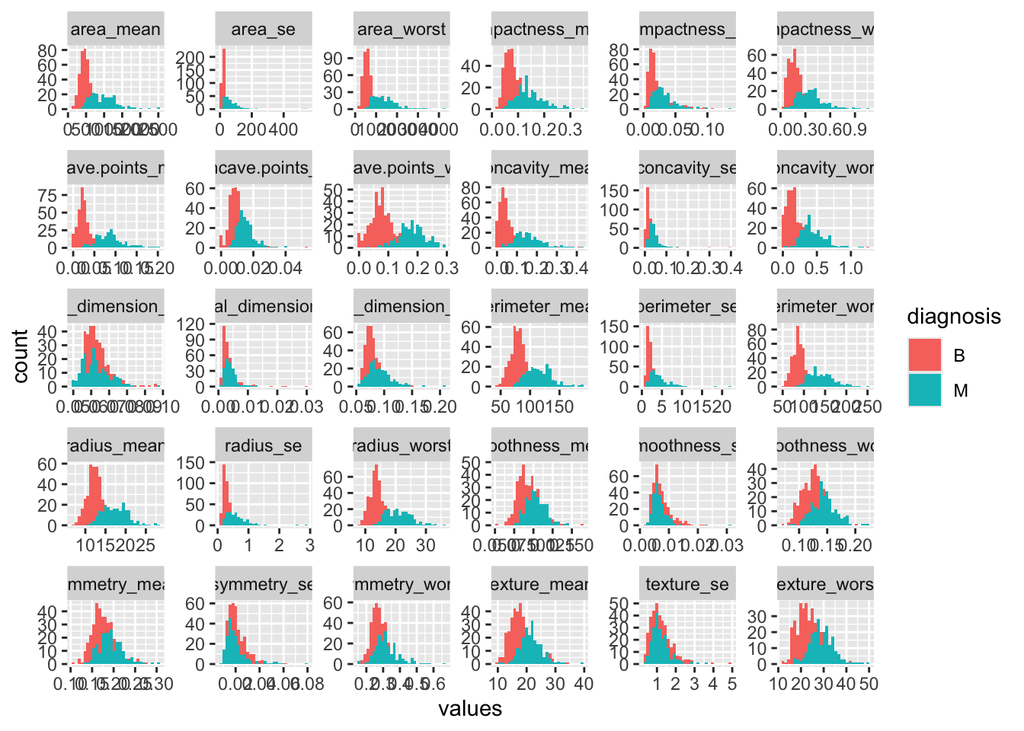

```r
# plot the variables
ggplot(pivot_df, aes(x=values, fill = diagnosis)) +
  geom_histogram(position = "identity", bins = 30) + # overlay the diagnosis
  facet_wrap(~variable, scales = "free") # allow x-axis to be independent of each other
```

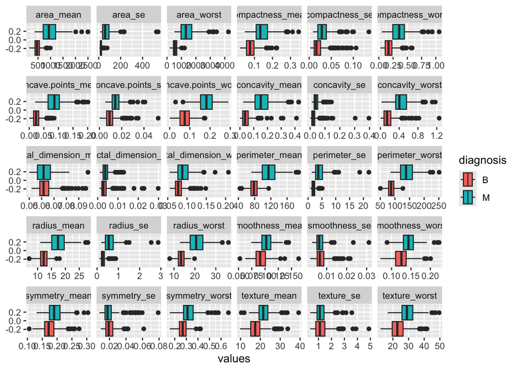

```r
# Review boxplot
ggplot(pivot_df, aes(x = values, fill = diagnosis)) +
  geom_boxplot()+
  facet_wrap(~variable, scales = "free_x")
```

```r
# create a mean subset dataframe for easier visuals to review
FNA_sub.mean <- FNA %>%
  select(diagnosis, radius_mean, texture_mean, perimeter_mean, area_mean, smoothness_mean, compactness_mean, concavity_mean, concave.points_mean, symmetry_mean, fractal_dimension_mean, malignant) # select all mean data

# need to create a df for a facet wrap, using pivot longer
pivot_mean <- FNA_sub.mean %>%
  pivot_longer(cols = where(is.numeric) & ! diagnosis & ! malignant, # make sure the response isn't chosen
               names_to = "variable",
               values_to = "values")
```

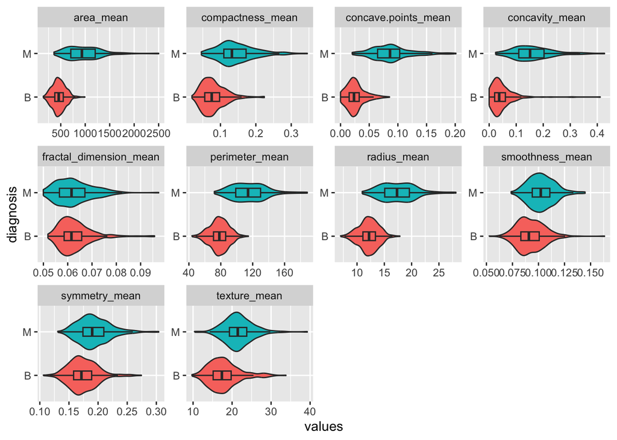

```r
# reviewing the mean data subset
ggplot(pivot_mean, aes(x = values, y = diagnosis, fill = diagnosis)) +
  geom_violin()+ # add violinplot
  geom_boxplot(width = 0.2, outlier.shape = NA)+ # overlay a boxplot
  facet_wrap(~variable, scales = "free") +
  theme(legend.position = "none") # no need for legend
```

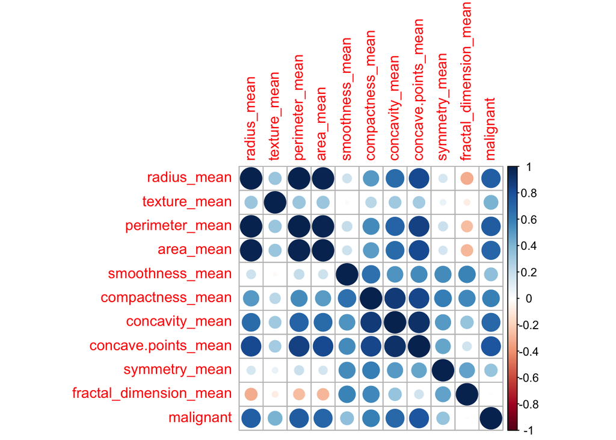

```r
#mean subset correlation plot
numeric_cols.mean <- sapply(FNA_sub.mean, is.numeric)
corrplot(cor(FNA_sub.mean[,numeric_cols.mean]), method = "circle")
```

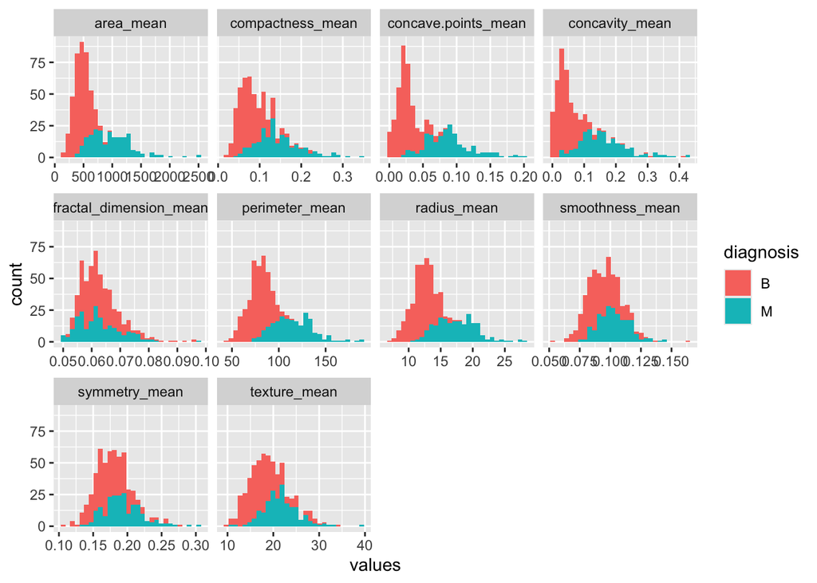

```r
# reviewing the mean data subset histograms
ggplot(pivot_mean, aes(x = values, fill = diagnosis)) +
  geom_histogram(bins = 30)+
  facet_wrap(~variable, scales = "free_x")
```

```r
# create a se subset dataframe
FNA_sub.se <- FNA %>%
  select(diagnosis, radius_se, texture_se, perimeter_se, area_se, smoothness_se, compactness_se, concavity_se, concave.points_se, symmetry_se, fractal_dimension_se, malignant)

# need to create a df for a facet wrap, using pivot longer
pivot_se <- FNA_sub.se %>%
  pivot_longer(cols = where(is.numeric) & ! diagnosis & ! malignant, # make sure the response isn't choosen
               names_to = "variable",
               values_to = "values")
```

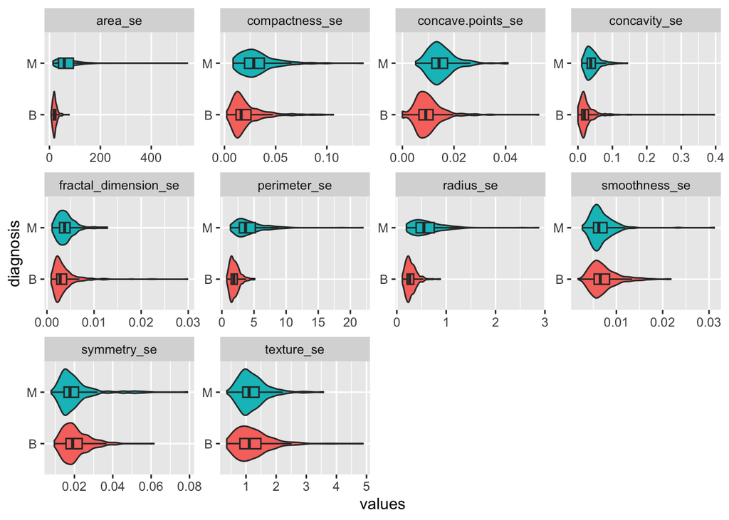

```r
# reviewing the se data subset
ggplot(pivot_se, aes(x = values, y = diagnosis, fill = diagnosis)) +
  geom_violin()+
  geom_boxplot(width = 0.2, outlier.shape = NA)+ # overlay a boxplot
  facet_wrap(~variable, scales = "free") +
  theme(legend.position = "none") # no need for legend
```

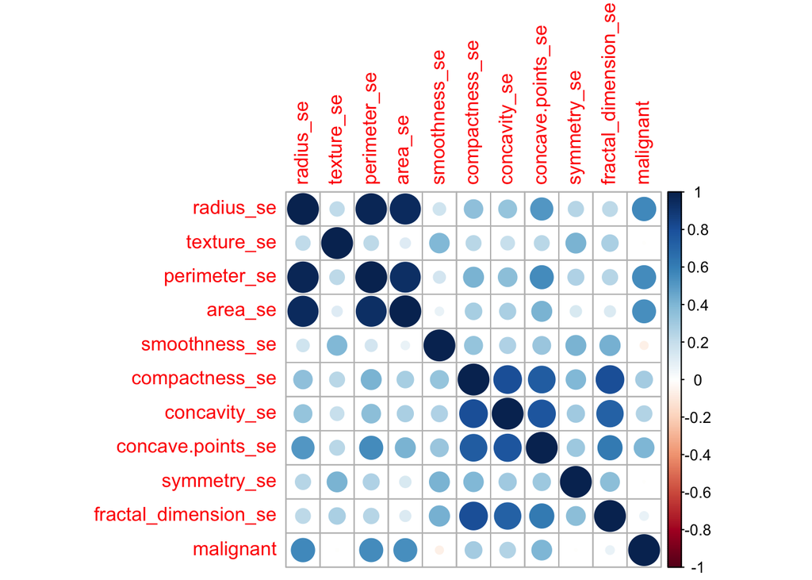

```r
#se subset correlation plot
numeric_cols.se <- sapply(FNA_sub.se, is.numeric)
corrplot(cor(FNA_sub.se[,numeric_cols.se]), method = "circle")
```

```r
# create a 'worst' subset dataframe
FNA_sub.worst <- FNA %>%
  select(diagnosis, radius_worst, texture_worst, perimeter_worst, area_worst, smoothness_worst, compactness_worst, concavity_worst, concave.points_worst, symmetry_worst, fractal_dimension_worst, malignant)

# need to create a df for a facet wrap, using pivot longer
pivot_worst <- FNA_sub.worst %>%
  pivot_longer(cols = where(is.numeric) & ! diagnosis & ! malignant, # make sure the response isn't chosen
               names_to = "variable",
               values_to = "values")
```

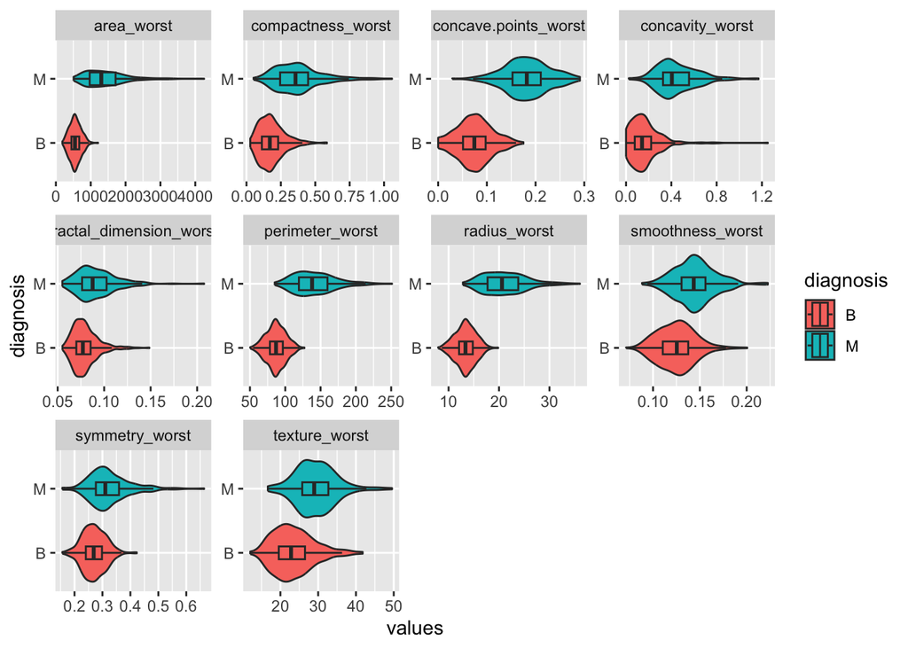

```r
# reviewing the worst data subset
ggplot(pivot_worst, aes(x = values, y = diagnosis, fill = diagnosis)) +
  geom_violin()+
  geom_boxplot(width = 0.2, outlier.shape = NA)+ # overlay a boxplot
  facet_wrap(~variable, scales = "free")
```

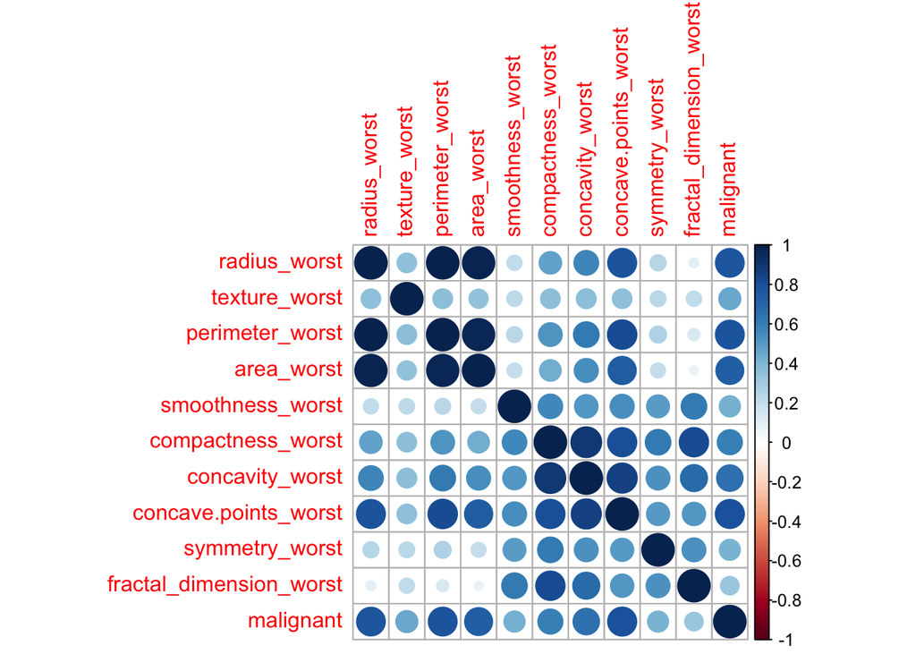

```r
#worst subset correlation plot
numeric_cols.worst <- sapply(FNA_sub.worst, is.numeric)
corrplot(cor(FNA_sub.worst[,numeric_cols.worst]), method = "circle")
```

```r
#install and load packages
library(rpart)
library(partykit)
library(tidymodels)
library(randomForest)
library(yardstick)
```

## Split the data into test and training data sets

- Divide the data into a training and a test set. Glimpse the training data.

```r
set.seed(1842) # set the seed to 1842

# split the data
FNA_split <- initial_split(FNA,prop=0.8)

# create the training and test data set
FNA_train <- training(FNA_split)
FNA_test <- testing(FNA_split)

# review the training data
glimpse(FNA_train)
```

```
Rows: 455
Columns: 32
$ diagnosis               <fct> M, B, B, M, B, M, M, M, B, B, B, B, B, B, B, B…
$ radius_mean             <dbl> 20.290, 13.560, 8.888, 25.730, 14.220, 20.340,…
$ texture_mean            <dbl> 14.34, 13.90, 14.64, 17.46, 27.85, 21.51, 20.8…
$ perimeter_mean          <dbl> 135.10, 88.59, 58.79, 174.20, 92.55, 135.90, 9…
$ area_mean               <dbl> 1297.0, 561.3, 244.0, 2010.0, 623.9, 1264.0, 5…
$ smoothness_mean         <dbl> 0.10030, 0.10510, 0.09783, 0.11490, 0.08223, 0…
$ compactness_mean        <dbl> 0.13280, 0.11920, 0.15310, 0.23630, 0.10390, 0…
$ concavity_mean          <dbl> 0.198000, 0.078600, 0.086060, 0.336800, 0.1103…
$ concave.points_mean     <dbl> 0.104300, 0.044510, 0.028720, 0.191300, 0.0440…
$ symmetry_mean           <dbl> 0.1809, 0.1962, 0.1902, 0.1956, 0.1342, 0.2569…
$ fractal_dimension_mean  <dbl> 0.05883, 0.06303, 0.08980, 0.06121, 0.06129, 0…
$ radius_se               <dbl> 0.7572, 0.2569, 0.5262, 0.9948, 0.3354, 0.5702…
$ texture_se              <dbl> 0.7813, 0.4981, 0.8522, 0.8509, 2.3240, 1.0230…
```

[output cut: 19 more lines]

## Build a classification algorithm using decision trees (prune your tree appropriately)

```r
# set a formula
formula_FNA <- as.formula(diagnosis ~ radius_mean + texture_mean + perimeter_mean + area_mean + smoothness_mean + compactness_mean + concavity_mean + concave.points_mean + symmetry_mean + fractal_dimension_mean + radius_se + texture_se + perimeter_se + area_se + smoothness_se + compactness_se + concavity_se + concave.points_se + symmetry_se + fractal_dimension_se + radius_worst + texture_worst +  perimeter_worst + area_worst + smoothness_worst + compactness_worst + concavity_worst +  concave.points_worst + symmetry_worst + fractal_dimension_worst)
```

```r
#create a decision tree from the training data set
FNA_Dtree <- rpart(formula_FNA ,data=FNA_train, method = "class")
FNA_Dtree
```

```
n= 455

node), split, n, loss, yval, (yprob)
      * denotes terminal node

 1) root 455 180 B (0.60439560 0.39560440)
   2) perimeter_worst< 105.95 274  17 B (0.93795620 0.06204380)
     4) concave.points_worst< 0.1589 264   8 B (0.96969697 0.03030303) *
     5) concave.points_worst>=0.1589 10   1 M (0.10000000 0.90000000) *
   3) perimeter_worst>=105.95 181  18 M (0.09944751 0.90055249)
     6) texture_worst< 20.645 20   8 B (0.60000000 0.40000000)
      12) concave.points_mean< 0.071265 12   0 B (1.00000000 0.00000000) *
      13) concave.points_mean>=0.071265 8   0 M (0.00000000 1.00000000) *
     7) texture_worst>=20.645 161   6 M (0.03726708 0.96273292) *
```

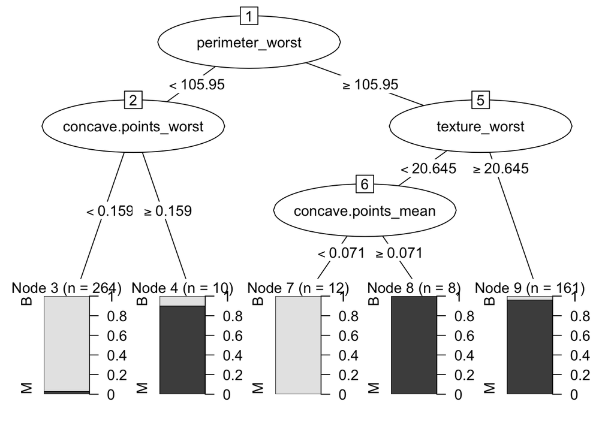

```r
# plot the tree
plot(as.party(FNA_Dtree))
```

```r
#Calculate the predictions for the test data
FNA_test$preds <- predict(FNA_Dtree,newdata = FNA_test, type = "class")

confusion_dTree <- table(FNA_test$diagnosis,FNA_test$preds,
                   dnn=c("actual", "predicted"))
confusion_dTree
```

```
      predicted
actual  B  M
     B 74  8
     M  1 31
```

```r
# calculate the accuracy
accuracy_tree <- sum(diag(confusion_dTree))/sum(confusion_dTree)
accuracy_tree * 100 # for percentage
```

```
[1] 92.10526
```

```r
#verifying improvement
printcp(FNA_Dtree) # cross validation error is the best at nplit 4.
```

```
Classification tree:
rpart(formula = formula_FNA, data = FNA_train, method = "class")

Variables actually used in tree construction:
[1] concave.points_mean  concave.points_worst perimeter_worst
[4] texture_worst

Root node error: 180/455 = 0.3956

n= 455

        CP nsplit rel error  xerror     xstd
1 0.805556      0  1.000000 1.00000 0.057946
2 0.044444      1  0.194444 0.29444 0.038017
3 0.033333      2  0.150000 0.28889 0.037703
4 0.010000      4  0.083333 0.25000 0.035377
```

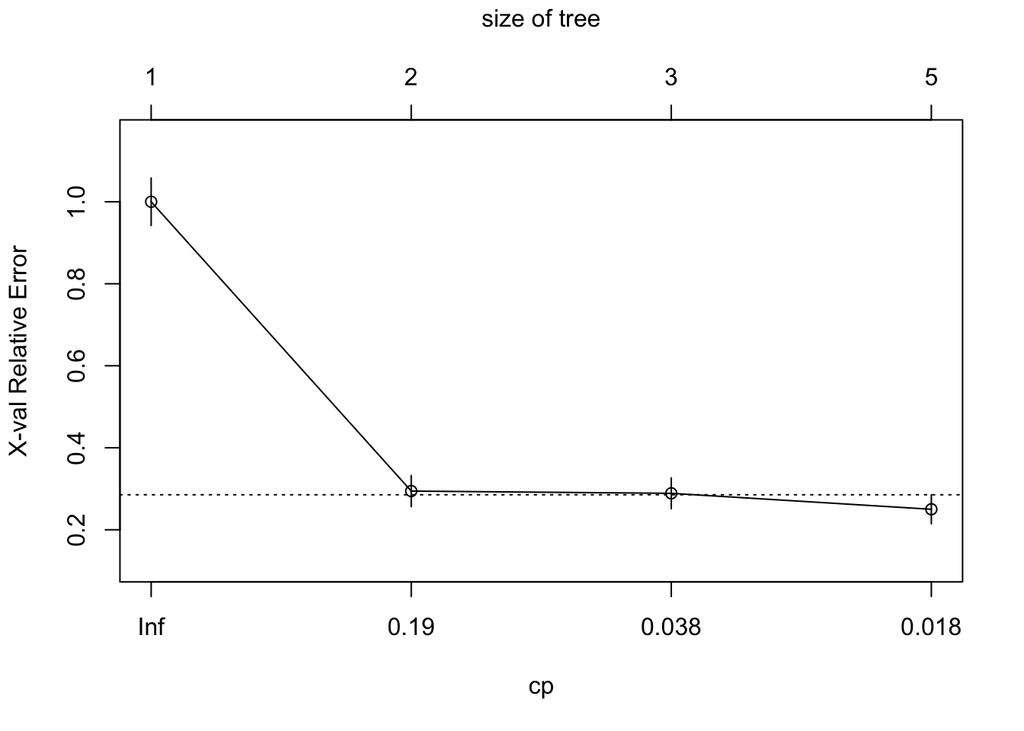

```r
# review cp plot
plotcp(FNA_Dtree)
```

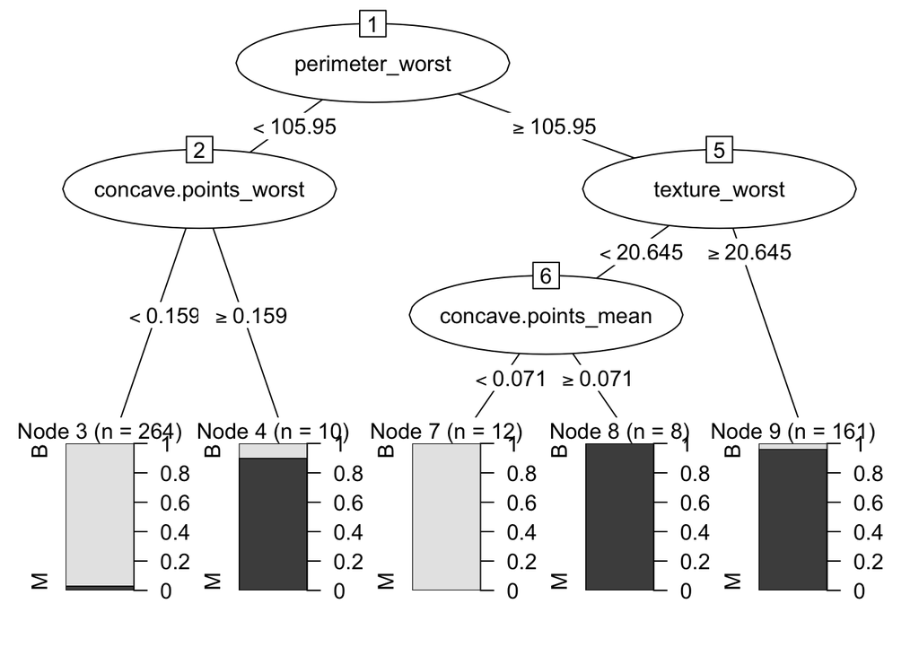

```r
# lowest xerror has a cp = 0.01, a prune tree using cp=0.01 will not change anything
new_tree = rpart::prune(FNA_Dtree, cp = 0.01)
# plot the tree
plot(as.party(new_tree))
```

## Build a classification algorithm using random forests or bagging (adjust the parameters of the forest appropriately).

```r
p <- length(c("radius_mean", "texture_mean","perimeter_mean","area_mean", "smoothness_mean","compactness_mean","concavity_mean","concave.points_mean", "symmetry_mean","fractal_dimension_mean","radius_se","texture_se","perimeter_se", "area_se","smoothness_se","compactness_se","concavity_se","concave.points_se", "symmetry_se","fractal_dimension_se","radius_worst","texture_worst", "perimeter_worst","area_worst","smoothness_worst","compactness_worst", "concavity_worst","concave.points_worst", "symmetry_worst", "fractal_dimension_worst"))

p
```

```
[1] 30
```

- Model, mtry=5, ntree = 500

```r
# set seed for model reproducibility
set.seed(1842)

# m=p, ntree = 500
forest_500 <- randomForest(formula_FNA, data = FNA_train, mtry=5, ntree=500)

#display model
forest_500
```

```
Call:
 randomForest(formula = formula_FNA, data = FNA_train, mtry = 5,      ntree = 500)
               Type of random forest: classification
                     Number of trees: 500
No. of variables tried at each split: 5

        OOB estimate of  error rate: 3.74%
Confusion matrix:
    B   M class.error
B 267   8  0.02909091
M   9 171  0.05000000
```

```r
#review the importance
importance(forest_500)
```

```
                        MeanDecreaseGini
radius_mean                    6.2783761
texture_mean                   3.2781098
perimeter_mean                 9.5678685
area_mean                      9.7238937
smoothness_mean                1.4645311
compactness_mean               2.2320075
concavity_mean                15.6490452
concave.points_mean           23.1578425
symmetry_mean                  0.6951788
fractal_dimension_mean         0.6438891
radius_se                      2.7148400
texture_se                     0.9691383
perimeter_se                   2.5964617
area_se                        6.7789671
smoothness_se                  0.8827664
compactness_se                 0.7433791
concavity_se                   1.4372453
concave.points_se              0.7907262
symmetry_se                    0.7573155
fractal_dimension_se           1.2645279
radius_worst                  23.9062409
texture_worst                  4.0924061
perimeter_worst               26.0081047
area_worst                    24.8694168
smoothness_worst               3.2420673
compactness_worst              3.0465487
concavity_worst               10.1702955
concave.points_worst          25.9144450
symmetry_worst                 2.6029485
fractal_dimension_worst        1.3532581
```

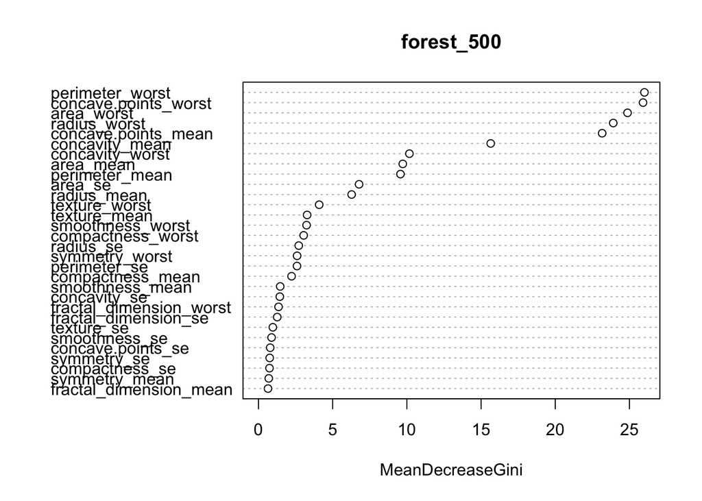

```r
varImpPlot(forest_500, sort = TRUE)
```

- Using the mtry = 5 model, predict the test data

```r
#for reproducibility
set.seed(1842)

# use model to predict
forest_pred<- predict(forest_500,newdata = FNA_test,"class")
```

```r
#make a confusion matrix for the test data
confusion_mat_forest <- table(forest_pred,FNA_test$diagnosis)
confusion_mat_forest
```

```
forest_pred  B  M
          B 78  1
          M  4 31
```

- Approximately 4.39% missclassified, which aligns with the OOB estimate error.

```r
# missclassified
1-sum(diag(confusion_mat_forest))/sum(confusion_mat_forest)
```

```
[1] 0.04385965
```

## Build a classification algorithm using K-Nearest Neighbors (tune the value of K appropriately)

- Create the recipe from the formula and training data

```r
knn_recipe <- recipe(formula_FNA,data=FNA_train)
```

```r
# preprocessing recipe
knn_recipe%>%
  prep()%>% #
  bake(FNA_train)
```

| radius_mean | texture_mean | perimeter_mean | area_mean | smoothness_mean | compactness_mean | concavity_mean | concave.points_mean | symmetry_mean | fractal_dimension_mean | radius_se | texture_se | perimeter_se | area_se | smoothness_se | compactness_se | concavity_se | concave.points_se | symmetry_se | fractal_dimension_se | radius_worst | texture_worst | perimeter_worst | area_worst | smoothness_worst | compactness_worst | concavity_worst | concave.points_worst | symmetry_worst | fractal_dimension_worst | … |
| --- | --- | --- | --- | --- | --- | --- | --- | --- | --- | --- | --- | --- | --- | --- | --- | --- | --- | --- | --- | --- | --- | --- | --- | --- | --- | --- | --- | --- | --- | --- |
| 20.290 | 14.34 | 135.10 | 1297.0 | 0.10030 | 0.13280 | 0.1980000 | 0.104300 | 0.1809 | 0.05883 | 0.7572 | 0.7813 | 5.4380 | 94.440 | 0.011490 | 0.024610 | 0.0568800 | 0.018850 | 0.017560 | 0.0051150 | 22.540 | 16.67 | 152.20 | 1575.0 | 0.13740 | 0.20500 | 0.400000 | 0.162500 | 0.2364 | 0.07678 | … |
| 13.560 | 13.90 | 88.59 | 561.3 | 0.10510 | 0.11920 | 0.0786000 | 0.044510 | 0.1962 | 0.06303 | 0.2569 | 0.4981 | 2.0110 | 21.030 | 0.005851 | 0.023140 | 0.0254400 | 0.008360 | 0.018420 | 0.0029180 | 14.980 | 17.13 | 101.10 | 686.6 | 0.13760 | 0.26980 | 0.257700 | 0.090900 | 0.3065 | 0.08177 | … |
| 8.888 | 14.64 | 58.79 | 244.0 | 0.09783 | 0.15310 | 0.0860600 | 0.028720 | 0.1902 | 0.08980 | 0.5262 | 0.8522 | 3.1680 | 25.440 | 0.017210 | 0.093680 | 0.0567100 | 0.017660 | 0.025410 | 0.0219300 | 9.733 | 15.67 | 62.56 | 284.4 | 0.12070 | 0.24360 | 0.143400 | 0.047860 | 0.2254 | 0.10840 | … |
| 25.730 | 17.46 | 174.20 | 2010.0 | 0.11490 | 0.23630 | 0.3368000 | 0.191300 | 0.1956 | 0.06121 | 0.9948 | 0.8509 | 7.2220 | 153.100 | 0.006369 | 0.042430 | 0.0426600 | 0.015080 | 0.023350 | 0.0033850 | 33.130 | 23.58 | 229.30 | 3234.0 | 0.15300 | 0.59370 | 0.645100 | 0.275600 | 0.3690 | 0.08815 | … |
| 14.220 | 27.85 | 92.55 | 623.9 | 0.08223 | 0.10390 | 0.1103000 | 0.044080 | 0.1342 | 0.06129 | 0.3354 | 2.3240 | 2.1050 | 29.960 | 0.006307 | 0.028450 | 0.0385000 | 0.010110 | 0.011850 | 0.0035890 | 15.750 | 40.54 | 102.50 | 764.0 | 0.10810 | 0.24260 | 0.306400 | 0.082190 | 0.1890 | 0.07796 | … |
| 20.340 | 21.51 | 135.90 | 1264.0 | 0.11700 | 0.18750 | 0.2565000 | 0.150400 | 0.2569 | 0.06670 | 0.5702 | 1.0230 | 4.0120 | 69.060 | 0.005485 | 0.024310 | 0.0319000 | 0.013690 | 0.027680 | 0.0033450 | 25.300 | 31.86 | 171.10 | 1938.0 | 0.15920 | 0.44920 | 0.534400 | 0.268500 | 0.5558 | 0.10240 | … |
| 13.710 | 20.83 | 90.20 | 577.9 | 0.11890 | 0.16450 | 0.0936600 | 0.059850 | 0.2196 | 0.07451 | 0.5835 | 1.3770 | 3.8560 | 50.960 | 0.008805 | 0.030290 | 0.0248800 | 0.014480 | 0.014860 | 0.0054120 | 17.060 | 28.14 | 110.60 | 897.0 | 0.16540 | 0.36820 | 0.267800 | 0.155600 | 0.3196 | 0.11510 | … |
| 20.200 | 26.83 | 133.70 | 1234.0 | 0.09905 | 0.16690 | 0.1641000 | 0.126500 | 0.1875 | 0.06020 | 0.9761 | 1.8920 | 7.1280 | 103.600 | 0.008439 | 0.046740 | 0.0590400 | 0.025360 | 0.037100 | 0.0042860 | 24.190 | 33.81 | 160.00 | 1671.0 | 0.12780 | 0.34160 | 0.370300 | 0.215200 | 0.3271 | 0.07632 | … |
| 14.260 | 18.17 | 91.22 | 633.1 | 0.06576 | 0.05220 | 0.0247500 | 0.013740 | 0.1635 | 0.05586 | 0.2300 | 0.6690 | 1.6610 | 20.560 | 0.003169 | 0.013770 | 0.0107900 | 0.005243 | 0.011030 | 0.0019570 | 16.220 | 25.26 | 105.80 | 819.7 | 0.09445 | 0.21670 | 0.156500 | 0.075300 | 0.2636 | 0.07676 | … |
| 13.300 | 21.57 | 85.24 | 546.1 | 0.08582 | 0.06373 | 0.0334400 | 0.024240 | 0.1815 | 0.05696 | 0.2621 | 1.5390 | 2.0280 | 20.980 | 0.005498 | 0.020450 | 0.0179500 | 0.006399 | 0.018290 | 0.0019560 | 14.200 | 29.20 | 92.94 | 621.2 | 0.11400 | 0.16670 | 0.121200 | 0.056140 | 0.2637 | 0.06658 | … |

[output cut: 445 more lines]

```r
# covert hotel to numeric
knn_recipe <- knn_recipe%>%
  step_range(all_numeric_predictors(),min=0,max=1)
```

```r
# review the data
knn_prep <- prep(knn_recipe)

bake(knn_prep, new_data = NULL)
```

| radius_mean | texture_mean | perimeter_mean | area_mean | smoothness_mean | compactness_mean | concavity_mean | concave.points_mean | symmetry_mean | fractal_dimension_mean | radius_se | texture_se | perimeter_se | area_se | smoothness_se | compactness_se | concavity_se | concave.points_se | symmetry_se | fractal_dimension_se | radius_worst | texture_worst | perimeter_worst | area_worst | smoothness_worst | compactness_worst | concavity_worst | concave.points_worst | symmetry_worst | fractal_dimension_worst | … |
| --- | --- | --- | --- | --- | --- | --- | --- | --- | --- | --- | --- | --- | --- | --- | --- | --- | --- | --- | --- | --- | --- | --- | --- | --- | --- | --- | --- | --- | --- | --- |
| 0.62989256 | 0.19211618 | 0.63098611 | 0.48928950 | 0.43035118 | 0.34789277 | 0.463917526 | 0.518389662 | 0.37828283 | 0.18681550 | 0.233822198 | 0.1190961027 | 0.2205625972 | 0.1636875745 | 0.309981379 | 0.167918407 | 0.143636364 | 0.35707520 | 0.13617943 | 0.145799649 | 0.51974386 | 0.12393390 | 0.50694756 | 0.341574912 | 0.39724089 | 0.16673179 | 0.341880342 | 0.55841924 | 0.157500493 | 0.14259478 | … |
| 0.31137299 | 0.17385892 | 0.30958469 | 0.17722163 | 0.47368421 | 0.30617754 | 0.184161200 | 0.221222664 | 0.45555556 | 0.27527380 | 0.052652544 | 0.0390010747 | 0.0590868397 | 0.0265746230 | 0.111864526 | 0.156878061 | 0.064242424 | 0.15836333 | 0.14828052 | 0.069897600 | 0.25080043 | 0.13619403 | 0.25245281 | 0.123230436 | 0.39865582 | 0.23003282 | 0.220256410 | 0.31237113 | 0.295683028 | 0.17532468 | … |
| 0.09025510 | 0.20456432 | 0.10365559 | 0.04262990 | 0.40805272 | 0.41015889 | 0.201640112 | 0.142743539 | 0.42525253 | 0.83909014 | 0.150172008 | 0.1391481419 | 0.1136031664 | 0.0348114860 | 0.510944033 | 0.686664464 | 0.143207071 | 0.33453306 | 0.24663702 | 0.726724984 | 0.06414088 | 0.09728145 | 0.06051098 | 0.024380653 | 0.27909445 | 0.20443889 | 0.122564103 | 0.16446735 | 0.135817071 | 0.34999344 | … |
| 0.88735861 | 0.32157676 | 0.90118167 | 0.79172853 | 0.56215582 | 0.66535795 | 0.789128397 | 0.950795229 | 0.45252525 | 0.23694187 | 0.319862394 | 0.1387804740 | 0.3046223437 | 0.2732509273 | 0.130063591 | 0.301754439 | 0.107727273 | 0.28566016 | 0.21765070 | 0.086031535 | 0.89647812 | 0.30810235 | 0.89093082 | 0.749311836 | 0.50760524 | 0.54644029 | 0.551367521 | 0.94707904 | 0.418884289 | 0.21717172 | … |
| 0.34260968 | 0.75269710 | 0.33694976 | 0.20377519 | 0.26722037 | 0.25924790 | 0.258434864 | 0.219085487 | 0.14242424 | 0.23862679 | 0.081079124 | 0.5554047175 | 0.0635159968 | 0.0432538037 | 0.127885325 | 0.196758494 | 0.097222222 | 0.19151354 | 0.05583385 | 0.093079336 | 0.27819281 | 0.76012793 | 0.25942527 | 0.142253244 | 0.18995401 | 0.20346202 | 0.261880342 | 0.28243986 | 0.064064656 | 0.15033451 | … |
| 0.63225898 | 0.48962656 | 0.63651441 | 0.47529162 | 0.58111402 | 0.51567389 | 0.600984067 | 0.747514911 | 0.76212121 | 0.35256950 | 0.166105378 | 0.1874540415 | 0.1533713424 | 0.1162835872 | 0.099005727 | 0.165665275 | 0.080555556 | 0.25932942 | 0.27857826 | 0.084649614 | 0.61792956 | 0.52878465 | 0.60107575 | 0.430790405 | 0.55146799 | 0.40528290 | 0.456752137 | 0.92268041 | 0.787108220 | 0.31063886 | … |
| 0.31847224 | 0.46141079 | 0.32071039 | 0.18426299 | 0.59826668 | 0.44512607 | 0.219447048 | 0.297465209 | 0.57373737 | 0.51705981 | 0.170921601 | 0.2875728265 | 0.1460208265 | 0.0824769611 | 0.215648386 | 0.210577703 | 0.062828283 | 0.27429437 | 0.09818765 | 0.156060418 | 0.32479545 | 0.42963753 | 0.29976592 | 0.174941015 | 0.59533074 | 0.32615661 | 0.228888889 | 0.53470790 | 0.321506012 | 0.39393939 | … |
| 0.62563302 | 0.71037344 | 0.62131159 | 0.46256628 | 0.41906653 | 0.45248758 | 0.384489222 | 0.628727634 | 0.41161616 | 0.21566976 | 0.313090712 | 0.4332258612 | 0.3001931866 | 0.1807963422 | 0.202789586 | 0.334124433 | 0.149090909 | 0.48039401 | 0.41112737 | 0.117159322 | 0.57844184 | 0.58075693 | 0.54579411 | 0.365169092 | 0.32932437 | 0.30017193 | 0.316495726 | 0.73951890 | 0.336290164 | 0.13957759 | … |
| 0.34450282 | 0.35103734 | 0.32775897 | 0.20767762 | 0.11853390 | 0.10066867 | 0.057989691 | 0.068290258 | 0.29040404 | 0.12426285 | 0.042911461 | 0.0873352565 | 0.0425952976 | 0.0256967714 | 0.017636932 | 0.086505242 | 0.027247475 | 0.09931805 | 0.04429560 | 0.036696931 | 0.29491284 | 0.35287846 | 0.27586035 | 0.155942784 | 0.09338521 | 0.17816114 | 0.133760684 | 0.25876289 | 0.211117682 | 0.14246360 | … |
| 0.29906763 | 0.49211618 | 0.28643494 | 0.17077413 | 0.29962986 | 0.13603460 | 0.078350515 | 0.120477137 | 0.38131313 | 0.14743050 | 0.054535578 | 0.3333898976 | 0.0598878575 | 0.0264812345 | 0.099462460 | 0.136674978 | 0.045328283 | 0.12121614 | 0.14645129 | 0.036662383 | 0.22305229 | 0.45788913 | 0.21181334 | 0.107156901 | 0.23169438 | 0.12931776 | 0.103589744 | 0.19292096 | 0.211314804 | 0.07569198 | … |

[output cut: 445 more lines]

- Create the 5 fold cross validation

```r
# Create the folds
set.seed(1842)

my_fold <- vfold_cv(FNA_train, v=5)
```

- Tune the model, set the hyperparameters to tune

```r
# using tune(), set neighbors to tune
knn_tune <- nearest_neighbor(neighbors = tune()) %>%
  set_engine("kknn")%>%
  set_mode("classification")
```

- Add tune to workflow

```r
# Add tunable model to workflow
wf_knn_tune <- workflow() %>%
  add_recipe(knn_recipe) %>%
  add_model(knn_tune)
```

- Create a grid of k = 3, 5, 7

```r
# k equal to 3, 5, and 7
grid_knn <- tibble(neighbors = c(3,5,7))
```

- Tune a grid, add accuracy, specificity and sensitivity metrics

```r
library(yardstick)
# tune
tuned <- tune_grid(wf_knn_tune,
                   resamples = my_fold, # 5 fold x-validation
                   grid = grid_knn, # add grid for k = 3, 5, 7
                   metrics = metric_set(accuracy, sens, spec)) # add specified metrics
```

- Display collection metrics for k = 3, 5, 7

```r
# review the metrics
collect_metrics(tuned)
```

| neighbors | .metric | .estimator | mean | n | std_err | .config |
| --- | --- | --- | --- | --- | --- | --- |
| 3 | accuracy | binary | 0.9604396 | 5 | 0.0089275147 | pre0_mod1_post0 |
| 3 | sens | binary | 0.9712521 | 5 | 0.0066442798 | pre0_mod1_post0 |
| 3 | spec | binary | 0.9448711 | 5 | 0.0159236409 | pre0_mod1_post0 |
| 5 | accuracy | binary | 0.9604396 | 5 | 0.0089275147 | pre0_mod2_post0 |
| 5 | sens | binary | 0.9712521 | 5 | 0.0066442798 | pre0_mod2_post0 |
| 5 | spec | binary | 0.9448711 | 5 | 0.0159236409 | pre0_mod2_post0 |
| 7 | accuracy | binary | 0.9692308 | 5 | 0.0080752409 | pre0_mod3_post0 |
| 7 | sens | binary | 0.9817201 | 5 | 0.0006930043 | pre0_mod3_post0 |
| 7 | spec | binary | 0.9491759 | 5 | 0.0220320668 | pre0_mod3_post0 |

- Identify the best k based on accuracy

```r
# find the best k based on accuracy
best_k <-select_best(tuned, metric = "accuracy")
best_k
```

| neighbors | .config |
| --- | --- |
| 7 | pre0_mod3_post0 |

- Use the best k from above to set in the final workflow and fit

```r
# set the k at the best identified k
final_wf_knn <- finalize_workflow(wf_knn_tune, best_k)

final_fit <- fit(final_wf_knn, data = FNA_train)
```

- Provide a confusion matrix

```r
augment(new_data=FNA_test, final_fit) %>%
  conf_mat(truth = diagnosis, estimate = .pred_class)
```

```
          Truth
Prediction  B  M
         B 78  2
         M  4 30
```

- Provide accuracy, sensitivity, and specificity for this prediction

```r
# set the metrics
my_metrics <- metric_set(accuracy, sens, spec)

# list the predictions
predk <- augment(new_data=FNA_test, final_fit)

# Provide the tibble
my_metrics(predk, truth= diagnosis, estimate = .pred_class)
```

| .metric | .estimator | .estimate |
| --- | --- | --- |
| accuracy | binary | 0.9473684 |
| sens | binary | 0.9512195 |
| spec | binary | 0.9375000 |

## Build a classification algorithm using logistic regression (adjust the model structure appropriately).

need to review more, this has issues

- Build a tidy models recipe that predicts diagnostics

```r
#make a recipe
log_recipe <- recipe(formula_FNA,data=FNA_train)
```

```r
# preprocessing recipe
log_recipe%>%
  prep()%>% #
  bake(FNA_train)
```

| radius_mean | texture_mean | perimeter_mean | area_mean | smoothness_mean | compactness_mean | concavity_mean | concave.points_mean | symmetry_mean | fractal_dimension_mean | radius_se | texture_se | perimeter_se | area_se | smoothness_se | compactness_se | concavity_se | concave.points_se | symmetry_se | fractal_dimension_se | radius_worst | texture_worst | perimeter_worst | area_worst | smoothness_worst | compactness_worst | concavity_worst | concave.points_worst | symmetry_worst | fractal_dimension_worst | … |
| --- | --- | --- | --- | --- | --- | --- | --- | --- | --- | --- | --- | --- | --- | --- | --- | --- | --- | --- | --- | --- | --- | --- | --- | --- | --- | --- | --- | --- | --- | --- |
| 20.290 | 14.34 | 135.10 | 1297.0 | 0.10030 | 0.13280 | 0.1980000 | 0.104300 | 0.1809 | 0.05883 | 0.7572 | 0.7813 | 5.4380 | 94.440 | 0.011490 | 0.024610 | 0.0568800 | 0.018850 | 0.017560 | 0.0051150 | 22.540 | 16.67 | 152.20 | 1575.0 | 0.13740 | 0.20500 | 0.400000 | 0.162500 | 0.2364 | 0.07678 | … |
| 13.560 | 13.90 | 88.59 | 561.3 | 0.10510 | 0.11920 | 0.0786000 | 0.044510 | 0.1962 | 0.06303 | 0.2569 | 0.4981 | 2.0110 | 21.030 | 0.005851 | 0.023140 | 0.0254400 | 0.008360 | 0.018420 | 0.0029180 | 14.980 | 17.13 | 101.10 | 686.6 | 0.13760 | 0.26980 | 0.257700 | 0.090900 | 0.3065 | 0.08177 | … |
| 8.888 | 14.64 | 58.79 | 244.0 | 0.09783 | 0.15310 | 0.0860600 | 0.028720 | 0.1902 | 0.08980 | 0.5262 | 0.8522 | 3.1680 | 25.440 | 0.017210 | 0.093680 | 0.0567100 | 0.017660 | 0.025410 | 0.0219300 | 9.733 | 15.67 | 62.56 | 284.4 | 0.12070 | 0.24360 | 0.143400 | 0.047860 | 0.2254 | 0.10840 | … |
| 25.730 | 17.46 | 174.20 | 2010.0 | 0.11490 | 0.23630 | 0.3368000 | 0.191300 | 0.1956 | 0.06121 | 0.9948 | 0.8509 | 7.2220 | 153.100 | 0.006369 | 0.042430 | 0.0426600 | 0.015080 | 0.023350 | 0.0033850 | 33.130 | 23.58 | 229.30 | 3234.0 | 0.15300 | 0.59370 | 0.645100 | 0.275600 | 0.3690 | 0.08815 | … |
| 14.220 | 27.85 | 92.55 | 623.9 | 0.08223 | 0.10390 | 0.1103000 | 0.044080 | 0.1342 | 0.06129 | 0.3354 | 2.3240 | 2.1050 | 29.960 | 0.006307 | 0.028450 | 0.0385000 | 0.010110 | 0.011850 | 0.0035890 | 15.750 | 40.54 | 102.50 | 764.0 | 0.10810 | 0.24260 | 0.306400 | 0.082190 | 0.1890 | 0.07796 | … |
| 20.340 | 21.51 | 135.90 | 1264.0 | 0.11700 | 0.18750 | 0.2565000 | 0.150400 | 0.2569 | 0.06670 | 0.5702 | 1.0230 | 4.0120 | 69.060 | 0.005485 | 0.024310 | 0.0319000 | 0.013690 | 0.027680 | 0.0033450 | 25.300 | 31.86 | 171.10 | 1938.0 | 0.15920 | 0.44920 | 0.534400 | 0.268500 | 0.5558 | 0.10240 | … |
| 13.710 | 20.83 | 90.20 | 577.9 | 0.11890 | 0.16450 | 0.0936600 | 0.059850 | 0.2196 | 0.07451 | 0.5835 | 1.3770 | 3.8560 | 50.960 | 0.008805 | 0.030290 | 0.0248800 | 0.014480 | 0.014860 | 0.0054120 | 17.060 | 28.14 | 110.60 | 897.0 | 0.16540 | 0.36820 | 0.267800 | 0.155600 | 0.3196 | 0.11510 | … |
| 20.200 | 26.83 | 133.70 | 1234.0 | 0.09905 | 0.16690 | 0.1641000 | 0.126500 | 0.1875 | 0.06020 | 0.9761 | 1.8920 | 7.1280 | 103.600 | 0.008439 | 0.046740 | 0.0590400 | 0.025360 | 0.037100 | 0.0042860 | 24.190 | 33.81 | 160.00 | 1671.0 | 0.12780 | 0.34160 | 0.370300 | 0.215200 | 0.3271 | 0.07632 | … |
| 14.260 | 18.17 | 91.22 | 633.1 | 0.06576 | 0.05220 | 0.0247500 | 0.013740 | 0.1635 | 0.05586 | 0.2300 | 0.6690 | 1.6610 | 20.560 | 0.003169 | 0.013770 | 0.0107900 | 0.005243 | 0.011030 | 0.0019570 | 16.220 | 25.26 | 105.80 | 819.7 | 0.09445 | 0.21670 | 0.156500 | 0.075300 | 0.2636 | 0.07676 | … |
| 13.300 | 21.57 | 85.24 | 546.1 | 0.08582 | 0.06373 | 0.0334400 | 0.024240 | 0.1815 | 0.05696 | 0.2621 | 1.5390 | 2.0280 | 20.980 | 0.005498 | 0.020450 | 0.0179500 | 0.006399 | 0.018290 | 0.0019560 | 14.200 | 29.20 | 92.94 | 621.2 | 0.11400 | 0.16670 | 0.121200 | 0.056140 | 0.2637 | 0.06658 | … |

[output cut: 445 more lines]

```r
# covert hotel to numeric
log_recipe <- log_recipe%>%
  step_normalize(all_numeric_predictors())
```

- Build a workflow to fit a logistic regression with your recipe

```r
#specify the model, logistic regression
log_reg <- logistic_reg() %>%
  set_engine("glm") %>%
  set_mode("classification")

# combine in a Workflow
log_wf <- workflow() %>%
  add_model(log_reg)%>%
  add_recipe(log_recipe)
```

- Extract the fit

```r
#fit the model
my_fit <- fit(log_wf ,data=FNA_train)
my_fit
```

```
══ Workflow [trained] ══════════════════════════════════════════════════════════
Preprocessor: Recipe
Model: logistic_reg()

── Preprocessor ────────────────────────────────────────────────────────────────
1 Recipe Step

• step_normalize()

── Model ───────────────────────────────────────────────────────────────────────

Call:  stats::glm(formula = ..y ~ ., family = stats::binomial, data = data)

Coefficients:
            (Intercept)              radius_mean             texture_mean
                40.3088               -1709.1235                  -5.4171
         perimeter_mean                area_mean          smoothness_mean
              1686.2921                   3.3724                  83.0581
       compactness_mean           concavity_mean      concave.points_mean
              -371.3254                 117.4820                 -38.4785
          symmetry_mean   fractal_dimension_mean                radius_se
                -1.1721                 101.8299                 355.6615
             texture_se             perimeter_se                  area_se
                 0.4237                -314.3859                  93.4946
          smoothness_se           compactness_se             concavity_se
                 0.1739                  95.4299                 -46.5950
      concave.points_se              symmetry_se     fractal_dimension_se
                37.7604                 -25.5094                -107.6992
           radius_worst            texture_worst          perimeter_worst
               135.0037                  53.5096                 362.2832
             area_worst         smoothness_worst        compactness_worst
              -165.6370                 -48.1813                 -87.0530
        concavity_worst     concave.points_worst           symmetry_worst
                42.1047                 128.1882                  46.9438
fractal_dimension_worst
                98.9066

Degrees of Freedom: 454 Total (i.e. Null);  424 Residual
Null Deviance:      610.8
Residual Deviance: 3.075e-07    AIC: 62
```

- Provide a summary of the GLM object.

```r
# summary
my_fit%>%
  extract_fit_engine()%>%
  summary()
```

```
Call:
stats::glm(formula = ..y ~ ., family = stats::binomial, data = data)

Coefficients:
                          Estimate Std. Error z value Pr(>|z|)
(Intercept)              4.031e+01  9.782e+04   0.000    1.000
radius_mean             -1.709e+03  1.031e+06  -0.002    0.999
texture_mean            -5.417e+00  3.374e+04   0.000    1.000
perimeter_mean           1.686e+03  8.302e+05   0.002    0.998
area_mean                3.372e+00  4.191e+05   0.000    1.000
smoothness_mean          8.306e+01  4.133e+04   0.002    0.998
compactness_mean        -3.713e+02  1.216e+05  -0.003    0.998
concavity_mean           1.175e+02  1.563e+05   0.001    0.999
concave.points_mean     -3.848e+01  1.028e+05   0.000    1.000
symmetry_mean           -1.172e+00  1.917e+04   0.000    1.000
fractal_dimension_mean   1.018e+02  4.059e+04   0.003    0.998
radius_se                3.557e+02  9.754e+04   0.004    0.997
texture_se               4.237e-01  5.080e+04   0.000    1.000
perimeter_se            -3.144e+02  9.994e+04  -0.003    0.997
area_se                  9.349e+01  1.443e+05   0.001    0.999
smoothness_se            1.739e-01  2.520e+04   0.000    1.000
compactness_se           9.543e+01  3.820e+04   0.002    0.998
concavity_se            -4.659e+01  5.292e+04  -0.001    0.999
concave.points_se        3.776e+01  4.728e+04   0.001    0.999
symmetry_se             -2.551e+01  2.276e+04  -0.001    0.999
fractal_dimension_se    -1.077e+02  6.224e+04  -0.002    0.999
radius_worst             1.350e+02  9.204e+05   0.000    1.000
texture_worst            5.351e+01  6.996e+04   0.001    0.999
perimeter_worst          3.623e+02  1.881e+05   0.002    0.998
area_worst              -1.656e+02  1.155e+06   0.000    1.000
smoothness_worst        -4.818e+01  2.220e+04  -0.002    0.998
compactness_worst       -8.705e+01  3.331e+04  -0.003    0.998
concavity_worst          4.210e+01  9.705e+04   0.000    1.000
concave.points_worst     1.282e+02  8.013e+04   0.002    0.999
symmetry_worst           4.694e+01  2.873e+04   0.002    0.999
fractal_dimension_worst  9.891e+01  2.761e+04   0.004    0.997

(Dispersion parameter for binomial family taken to be 1)

    Null deviance: 6.1078e+02  on 454  degrees of freedom
Residual deviance: 3.0748e-07  on 424  degrees of freedom
AIC: 62

Number of Fisher Scoring iterations: 25
```